# Analiza zgłoszeń do urzędu patentowego RP na poziomie powiatów

Marcin Pawlicki

6/20/2020

## Przygotowanie danych z roku 2019

## Wizualizacja danych

### Ilość zgłoszeń do urzędu patentowego RP na poziomie powiatu

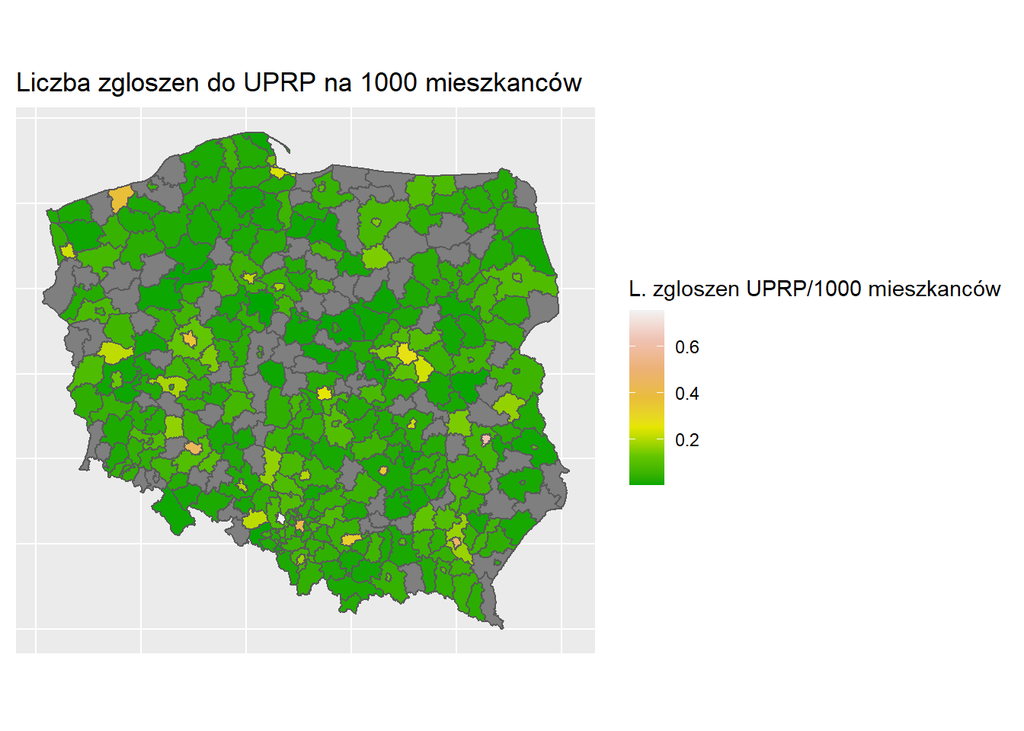

Wyszarzone powiaty na mapie oznaczają brak zgłoszeń do urzędu patentowego w danym powiecie.

Najwięcej zgłoszeń do urzędów patentowych na 1000 mieszkańców w 2019 roku miało miejsce w powiecie m. Gliwice (0.756/1000m.), następnie w powiecie m. Lublin (0.62/1000m.) i kolejno w powiecie m. Rzeszów (0.46/1000m.), m. Wrocław (0.44/1000m.) oraz m. Katowice (0.4/1000m.).

Pomijając powiaty, w których nie odnotowano w roku 2019 żadnych zgłoszeń do urzędu patentowego najmniejszy procent ludności dokonał zgłoszeń w powiatach Inowrocławskim (0.006/1000m.), Pilskim (0.007/1000m.), Płockim (0.009/1000m.), Raciborskim (0.0092/1000m.) oraz Łukowskim (0.0093/1000m.).

Powyższy podział można zaobserwować na wykresach słupkowych poniżej.

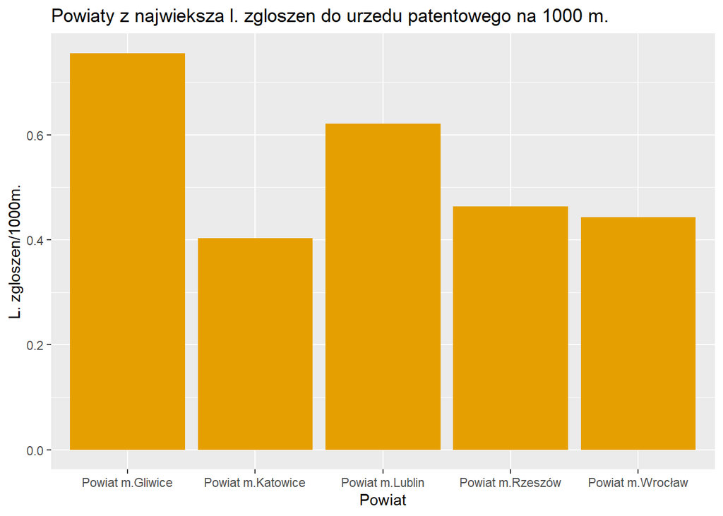

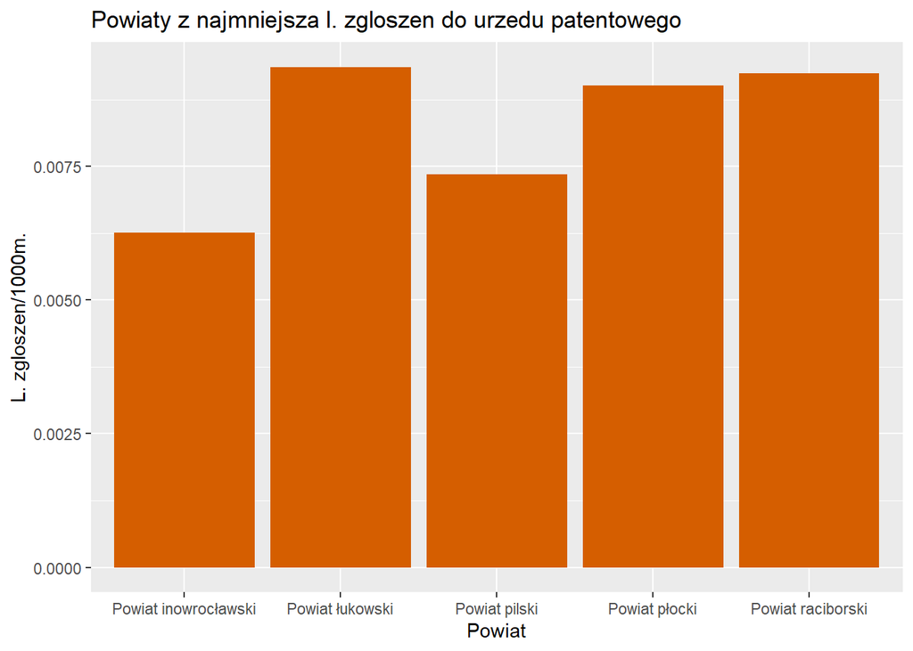

Jedną z ciekawych zależności jaką można by zweryfikować jest to czy liczba czytelników bibliotek publicznych ma jakiś wpływ na to jak często zgłaszane są w urzędzie patentowym innowacyjne projekty. Aby to zwizualizować można utworzyć wykres korelacji tych zmiennych:

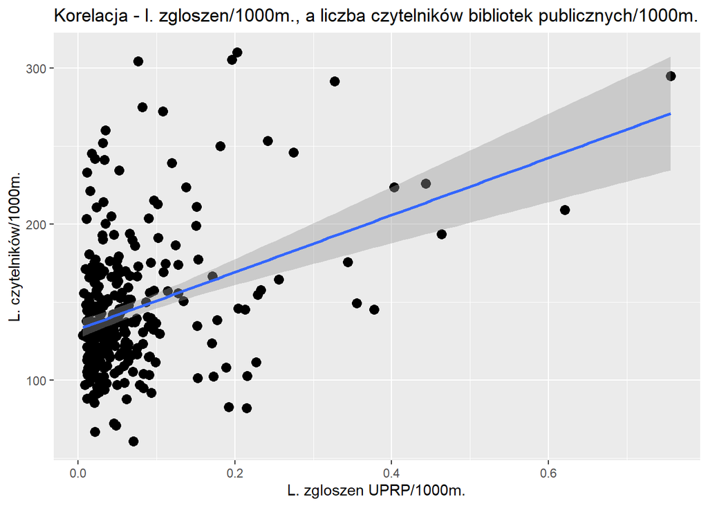

Z wykresu wynika, że lekka korelacja pomiędzy tymi zmiennymi jest możliwa. Można to sprawdzić wykorzystując współczynnik Pearsona:

```
##
##  Pearson's product-moment correlation
##
## data:  dane_lud_zgl_czyt$zgloszenia_na_1000_lud and dane_lud_zgl_czyt$czytelnicy_rok
## t = 8.9502, df = 296, p-value < 2.2e-16
## alternative hypothesis: true correlation is not equal to 0
## 95 percent confidence interval:
##  0.3671361 0.5464712
## sample estimates:
##       cor
## 0.4615055
```

Współczynnik korelacji Pearsona wynosi w tym przypadku 0.4615055, a więc jest to korelacja umiarkowana, a dodatni znak sugeruje, że przy wzroście liczby czytelników rośnie też liczba zgłoszeń do urzędu patentowego. P-wartość jest mniejsza niż 0,05 więc liczba czytelników bibliotek publicznych jest zmienną istotną.

Do analizy można dodać również mapę Polski z zaznaczonymi centroidami i ukształtowaniem terenu.

```
## Variable(s) "POL_msk_alt" contains positive and negative values, so midpoint is set to 0. Set midpoint = NA to show the full spectrum of the color palette.
```

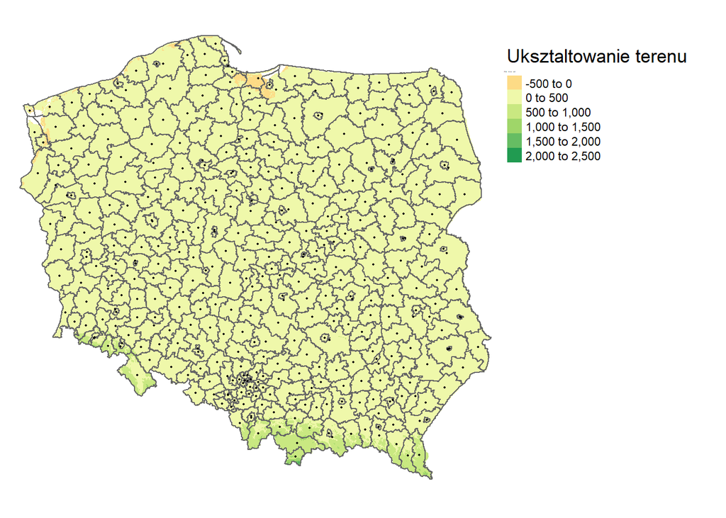

Poniżej znajdują się kartogramy z podziałem na każdą zmienną w tej analizie:

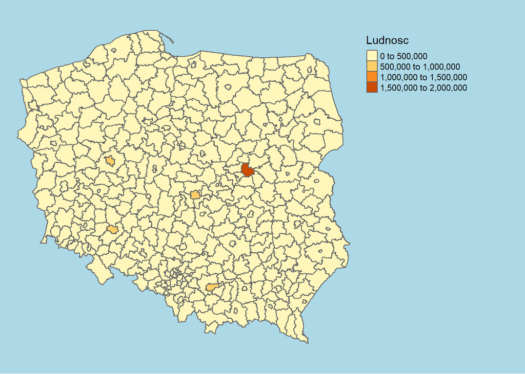

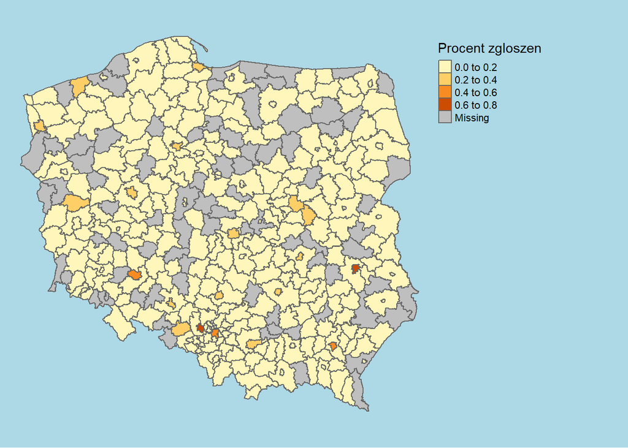

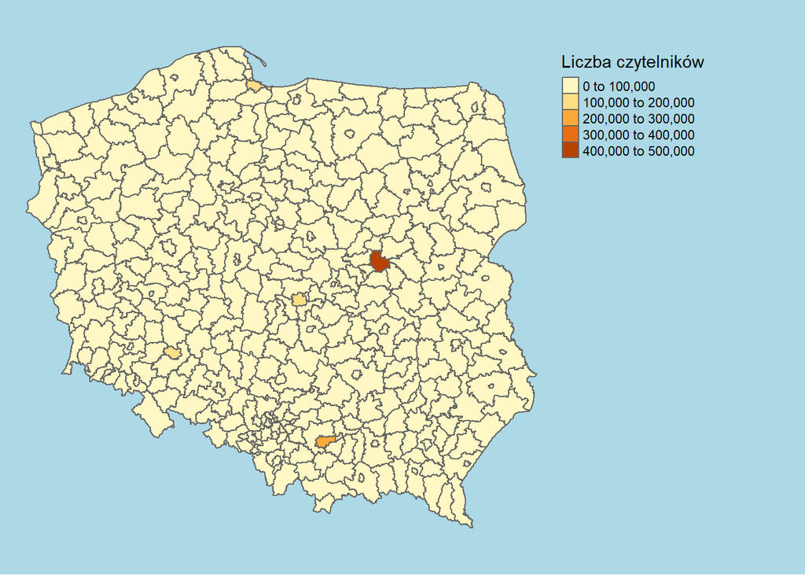